# Basic Statistics in R

Mean, median, Standard Deviation

```r
mean(iris$Petal.Length)
```

```
## [1] 3.758
```

```r
median(iris$Petal.Length)
```

```
## [1] 4.35
```

```r
quantile(iris$Petal.Length)
```

```
##   0%  25%  50%  75% 100%
## 1.00 1.60 4.35 5.10 6.90
```

Custom Percentile

```r
quantile(iris$Petal.Length,c(0.25,0.32,0.67,0.96))
```

```
##   25%   32%   67%   96%
## 1.600 1.836 4.900 6.108
```

InnerQuartile range = UpperQuartile - LowerQuartile

```r
IQR(iris$Petal.Length)
```

```
## [1] 3.5
```

Variance

The variance is a numerical measure of how the data values is dispersed around the mean.

```r
var(iris$Petal.Length)
```

```
## [1] 3.116278
```

The standard deviation of an observation variable is the square root of its variance

```r
sd(iris$Petal.Length)
```

```
## [1] 1.765298
```

Covariance of two variables x and y in a data set measures how the two are linearly related. A positive covariance would indicate a positive linear relationship between the variables, and a negative covariance would indicate the opposite.

```r
cov(iris$Sepal.Length,iris$Sepal.Width)
```

```
## [1] -0.042434
```

This can also be represented through plots

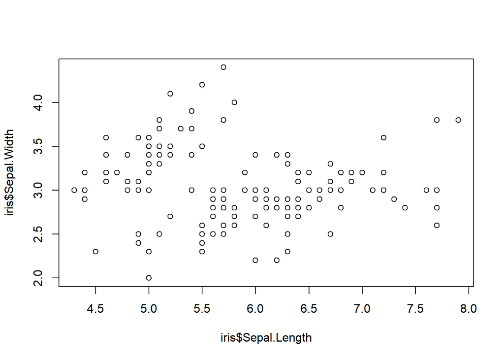

```r
plot(iris$Sepal.Length,iris$Sepal.Width)
```

```r
cov(iris$Sepal.Length,iris$Petal.Length)
```

```
## [1] 1.274315
```

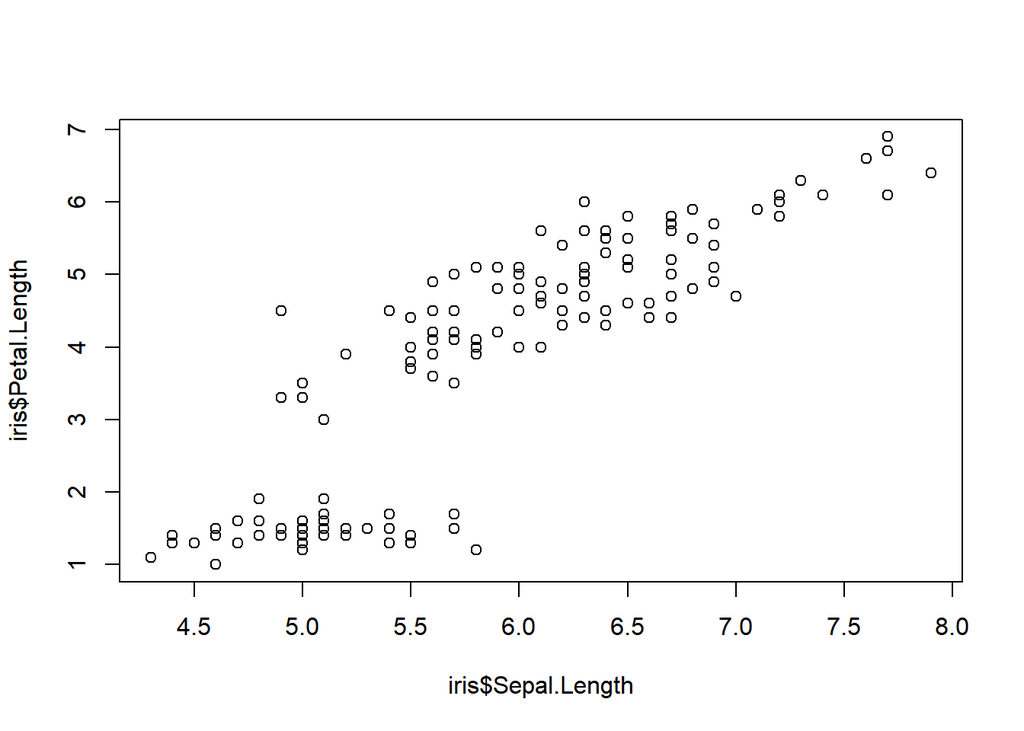

```r
plot(iris$Sepal.Length,iris$Petal.Length)
```

Correlation coefficient of two variables in a data set equals to their covariance divided by the product of their individual standard deviations. It is a normalized measurement of how the two are linearly related

```r
cor(iris$Sepal.Length,iris$Petal.Length)
```

```
## [1] 0.8717538
```

If the correlation coefficient is close to 1, it would indicate that the variables are positively linearly related and the scatter plot falls almost along a straight line with positive slope. For -1, it indicates that the variables are negatively linearly related and the scatter plot almost falls along a straight line with negative slope. And for zero, it would indicate a weak linear relationship between the variables.

### Central moment

central moment is a moment of a probability distribution of a random variable about the random variable’s mean; that is, it is the expected value of a specified integer power of the deviation of the random variable from the mean.

```r
library(e1071)
moment(iris$Petal.Length,order=3,center=TRUE)
```

```
## [1] -1.482073
```

```r
#3rd central moment
```

skewness is a measure of symmetry. As a rule, negative skewness indicates that the mean of the data values is less than the median, and the data distribution is left-skewed. Positive skewness would indicate that the mean of the data values is larger than the median, and the data distribution is right-skewed.

```r
skewness(iris$Sepal.Length)
```

```
## [1] 0.3086407
```

### Kurtosis

the excess kurtosis describes the tail shape of the data distribution. The normal distribution has zero excess kurtosis and thus the standard tail shape. It is said to be mesokurtic. Negative excess kurtosis would indicate a thin-tailed data distribution, and is said to be platykurtic. Positive excess kurtosis would indicate a fat-tailed distribution, and is said to be leptokurtic.

```r
kurtosis(iris$Petal.Length)
```

```
## [1] -1.416857
```

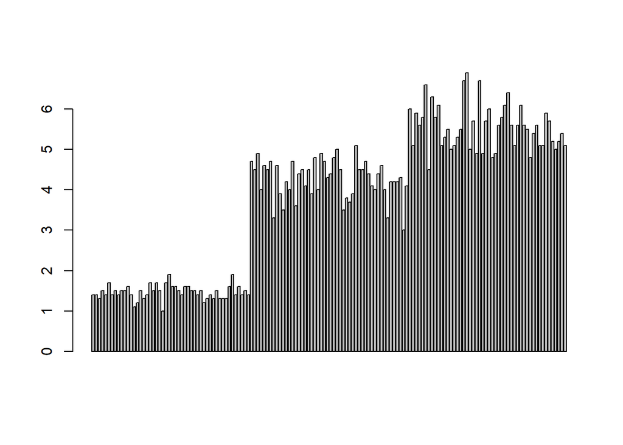

```r
barplot(iris$Petal.Length)
```

### max & min

```r
max(iris$Petal.Length)
```

```
## [1] 6.9
```

```r
min(iris$Petal.Length)
```

```
## [1] 1
```

Summary function provides all this information concisely and much more

```r
summary(iris)
```

```
##   Sepal.Length    Sepal.Width     Petal.Length    Petal.Width
##  Min.   :4.300   Min.   :2.000   Min.   :1.000   Min.   :0.100
##  1st Qu.:5.100   1st Qu.:2.800   1st Qu.:1.600   1st Qu.:0.300
##  Median :5.800   Median :3.000   Median :4.350   Median :1.300
##  Mean   :5.843   Mean   :3.057   Mean   :3.758   Mean   :1.199
##  3rd Qu.:6.400   3rd Qu.:3.300   3rd Qu.:5.100   3rd Qu.:1.800
##  Max.   :7.900   Max.   :4.400   Max.   :6.900   Max.   :2.500
##        Species
##  setosa    :50
##  versicolor:50
##  virginica :50
##
##
##
```

use tapply() to get the mean for Petal.Length grouped by Species

```r
tapply(iris$Petal.Length,iris$Species,mean)
```

```
##     setosa versicolor  virginica
##      1.462      4.260      5.552
```

get low & high

```r
range(iris$Petal.Length)
```

```
## [1] 1.0 6.9
```

```r
fivenum(iris$Petal.Length)
```

```
## [1] 1.00 1.60 4.35 5.10 6.90
```

```r
# min,lower-hinge, median,upper-hinge,max
```

Frequency distribution

```r
table(iris$Species)
```

```
##
##     setosa versicolor  virginica
##         50         50         50
```

Freq distribution in columnar format

```r
cbind(table(iris$Species))
```

```
##            [,1]
## setosa       50
## versicolor   50
## virginica    50
```

get Freq in percentages

```r
cbind(table(iris$Species)/nrow(iris))
```

```
##                 [,1]
## setosa     0.3333333
## versicolor 0.3333333
## virginica  0.3333333
```

relative frequency by splitting in bins

```r
table(cut(iris$Petal.Length,seq(1,7,by=0.5),right=FALSE))
```

```
##
## [1,1.5) [1.5,2) [2,2.5) [2.5,3) [3,3.5) [3.5,4) [4,4.5) [4.5,5) [5,5.5)
##      24      26       0       0       3       8      18      25      18
## [5.5,6) [6,6.5) [6.5,7)
##      17       7       4
```

Cummulative sum

```r
cumsum(table(iris$Species))
```

```
##     setosa versicolor  virginica
##         50        100        150
```

Binomial distribution with parameters n and p is the discrete probability distribution of the number of successes in a sequence of n independent experiments, each asking a yes–no question, and each with its own boolean-valued outcome: success/yes/true/one

Suppose you toss a coin 6 times and you want to find probability of getting head exactly 3 times. Probability of getting head for one event is 1/2 = 0.5

```r
dbinom(3,size=6,prob=0.5)
```

```
## [1] 0.3125
```

Use cumulative probability for finding probability less than qual to 3

```r
pbinom(3,size=6,prob=0.5)
```

```
## [1] 0.65625
```

Poisson Distribution is a discrete probability distribution that expresses the probability of a given number of events occurring in a fixed interval of time or space if these events occur with a known constant rate and independently of the time since the last event

If 5 chicken cross road daily on average, what is probability that 8 chickens will cross road today

```r
dpois(8,5)
```

```
## [1] 0.06527804
```

what is probability that 3 or less chicken will cross road today

```r
ppois(3,5)
```

```
## [1] 0.2650259
```

Continuous uniform distribution or rectangular distribution is a family of symmetric probability distributions such that for each member of the family, all intervals of the same length on the distribution’s support are equally probable.

```r
dunif(5, min = 1, max = 10)
```

```
## [1] 0.1111111
```

```r
punif(5, min = 1, max = 10)
```

```
## [1] 0.4444444
```

```r
runif(5, min = 1, max = 10)
```

```
## [1] 3.571746 4.662845 4.386790 7.032434 3.762044
```

Exponential distribution (known as the negative exponential distribution) is the probability distribution of the time between events in a Poisson point process, i.e., a process in which events occur continuously and independently at a constant average rate.

Suppose mean talking time for telemarketer is 3 minutes. find probablity that the call will be completed in less than 2 mins

```r
pexp(2,rate=1/3)
```

```
## [1] 0.4865829
```

Normal Distribution

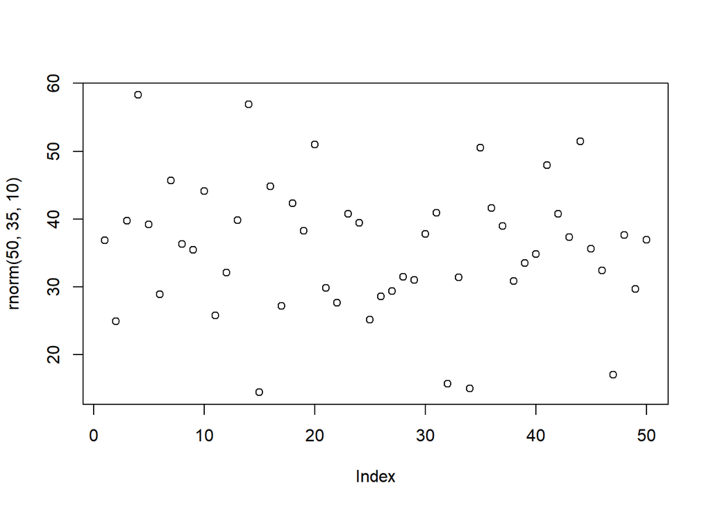

```r
plot(rnorm(50,35,10))
```

similarly can use following

dnorm(x, mean = 0, sd = 1, log = FALSE) pnorm(q, mean = 0, sd = 1, lower.tail = TRUE, log.p = FALSE) qnorm(p, mean = 0, sd = 1, lower.tail = TRUE, log.p = FALSE) rnorm(n, mean = 0, sd = 1)

```r
library(psych)
```

Describe function in psych package

```r
describe(iris)
```

|  | vars | n | mean | sd | median | trimmed | mad | min | max | range | skew | kurtosis | se |
| --- | --- | --- | --- | --- | --- | --- | --- | --- | --- | --- | --- | --- | --- |
| Sepal.Length | 1 | 150 | 5.843333 | 0.8280661 | 5.80 | 5.808333 | 1.03782 | 4.3 | 7.9 | 3.6 | 0.3086407 | -0.6058125 | 0.06761132 |
| Sepal.Width | 2 | 150 | 3.057333 | 0.4358663 | 3.00 | 3.043333 | 0.44478 | 2.0 | 4.4 | 2.4 | 0.3126147 | 0.1387047 | 0.03558833 |
| Petal.Length | 3 | 150 | 3.758000 | 1.7652982 | 4.35 | 3.760000 | 1.85325 | 1.0 | 6.9 | 5.9 | -0.2694109 | -1.4168574 | 0.14413600 |
| Petal.Width | 4 | 150 | 1.199333 | 0.7622377 | 1.30 | 1.184167 | 1.03782 | 0.1 | 2.5 | 2.4 | -0.1009166 | -1.3581792 | 0.06223645 |
| Species* | 5 | 150 | 2.000000 | 0.8192319 | 2.00 | 2.000000 | 1.48260 | 1.0 | 3.0 | 2.0 | 0.0000000 | -1.5199333 | 0.06689001 |

also can gather stats by grouping

```r
describeBy(iris,iris$Species)
```

```
##
##  Descriptive statistics by group
## group: setosa
##              vars  n mean   sd median trimmed  mad min max range skew
## Sepal.Length    1 50 5.01 0.35    5.0    5.00 0.30 4.3 5.8   1.5 0.11
## Sepal.Width     2 50 3.43 0.38    3.4    3.42 0.37 2.3 4.4   2.1 0.04
## Petal.Length    3 50 1.46 0.17    1.5    1.46 0.15 1.0 1.9   0.9 0.10
## Petal.Width     4 50 0.25 0.11    0.2    0.24 0.00 0.1 0.6   0.5 1.18
## Species*        5 50 1.00 0.00    1.0    1.00 0.00 1.0 1.0   0.0  NaN
##              kurtosis   se
## Sepal.Length    -0.45 0.05
## Sepal.Width      0.60 0.05
## Petal.Length     0.65 0.02
## Petal.Width      1.26 0.01
## Species*          NaN 0.00
## --------------------------------------------------------
## group: versicolor
##              vars  n mean   sd median trimmed  mad min max range  skew
## Sepal.Length    1 50 5.94 0.52   5.90    5.94 0.52 4.9 7.0   2.1  0.10
## Sepal.Width     2 50 2.77 0.31   2.80    2.78 0.30 2.0 3.4   1.4 -0.34
## Petal.Length    3 50 4.26 0.47   4.35    4.29 0.52 3.0 5.1   2.1 -0.57
## Petal.Width     4 50 1.33 0.20   1.30    1.32 0.22 1.0 1.8   0.8 -0.03
## Species*        5 50 2.00 0.00   2.00    2.00 0.00 2.0 2.0   0.0   NaN
##              kurtosis   se
## Sepal.Length    -0.69 0.07
## Sepal.Width     -0.55 0.04
## Petal.Length    -0.19 0.07
## Petal.Width     -0.59 0.03
## Species*          NaN 0.00
## --------------------------------------------------------
## group: virginica
##              vars  n mean   sd median trimmed  mad min max range  skew
## Sepal.Length    1 50 6.59 0.64   6.50    6.57 0.59 4.9 7.9   3.0  0.11
## Sepal.Width     2 50 2.97 0.32   3.00    2.96 0.30 2.2 3.8   1.6  0.34
## Petal.Length    3 50 5.55 0.55   5.55    5.51 0.67 4.5 6.9   2.4  0.52
## Petal.Width     4 50 2.03 0.27   2.00    2.03 0.30 1.4 2.5   1.1 -0.12
## Species*        5 50 3.00 0.00   3.00    3.00 0.00 3.0 3.0   0.0   NaN
##              kurtosis   se
## Sepal.Length    -0.20 0.09
## Sepal.Width      0.38 0.05
## Petal.Length    -0.37 0.08
## Petal.Width     -0.75 0.04
## Species*          NaN 0.00
```